# Introduction

This project was related to the Playground Series Season 3 Episode 8, hosted by Kaggle https://www.kaggle.com/competitions/playground-series-s3e8. A couple of notes as you walk through the notebook:

1) I purposely constrained myself to only use generalized linear models. Many in the competition used various ensemble models (for good reason) and outperformed my final submission, but this project is meant to showcase the multitudes of ways one can leverage linear models. It covers feature engineering, data transformations, model tuning, model evaluation and model selection. I believe it is a good notebook to understand my thought process as I try to tackle a problem relatively quickly.

2) This is by no means exhaustive. I didn't have time to leverage kernel regression or quantile regression during this project, which I believe would have improved the performance of the model.

3) This notebook contains only the necessary thought process leading to the final model. There were other directions I evaluated during the model creation (such as additional features or parameters within categorical variables) that I did not include within this notebook for brevities sake.

4) The initial linear model creation, feature selection/experimentation and evaluation was done primarily as experimentation. I find the best way to learn about the data is to actually play with the data, rather than gridsearch through all of the possibilities of models to find the best one. With that caveat, I will note that the first 6 models developed were done without much consideration for multicollinearity, partial F-tests etc. It was primarily an exercise to see what factors were in play and how the model performance reacts to different changes. Likewise, the final submission does not consider those aspects of model building. It would have been cumbersome to implement those considerations to model design I was implementing and I made the decision to disregard them in order to get a submission in by the competitions completion.

```python
# This Python 3 environment comes with many helpful analytics libraries installed
# It is defined by the kaggle/python Docker image: https://github.com/kaggle/docker-python
# For example, here's several helpful packages to load

#import libraries
import numpy as np # linear algebra
import pandas as pd # data processing, CSV file I/O (e.g. pd.read_csv)
import matplotlib.pyplot as plt
import seaborn as sns

#preprocessing library
from sklearn.preprocessing import StandardScaler
from sklearn.preprocessing import PolynomialFeatures
from scipy.stats import boxcox
from scipy.special import inv_boxcox

#importing models
from sklearn.linear_model import LinearRegression
import statsmodels.api as sm
import statsmodels.formula.api as smf
from sklearn.neighbors import KNeighborsRegressor

#import metrics & evaluation tools
from sklearn.metrics import mean_squared_error, mean_absolute_percentage_error,get_scorer_names, r2_score
from sklearn.model_selection import cross_val_score
from sklearn.feature_selection import f_regression, r_regression


# Input data files are available in the read-only "../input/" directory
# For example, running this (by clicking run or pressing Shift+Enter) will list all files under the input directory

import os
for dirname, _, filenames in os.walk('/kaggle/input'):
    for filename in filenames:
        print(os.path.join(dirname, filename))

# You can write up to 20GB to the current directory (/kaggle/working/) that gets preserved as output when you create a version using "Save & Run All"
# You can also write temporary files to /kaggle/temp/, but they won't be saved outside of the current session
```

```python
train_data = pd.read_csv("train.csv")
test_data = pd.read_csv("test.csv")
```

```python
len(train_data)
```

```
193573
```

```python
train_data.columns
```

```
Index(['id', 'carat', 'cut', 'color', 'clarity', 'depth', 'table', 'x', 'y',
       'z', 'price'],
      dtype='object')
```

```python
cont_cols = ['carat','depth','table','x','y','z']
cat_cols = ['cut','color','clarity']
```

# Exploratory Data Analysis

We do not have any NaNs within our data

```python
train_data[train_data.isna().any(axis=1)]
```

|  | id | carat | cut | color | clarity | depth | table | x | y | z | price |
| --- | --- | --- | --- | --- | --- | --- | --- | --- | --- | --- | --- |

However, we have instances where the continious variables appears to be inputted incorrectly.

```python
train_data[(train_data[cont_cols] == 0).any(axis=1)]
#we can mark them as outliers
outlier_indexes = train_data[(train_data[cont_cols] == 0).any(axis=1)].index
train_data['Outlier'] = 'False'
train_data.loc[outlier_indexes,'Outlier'] = 'True'
#and make the decision to remove them from our dataset later, if we so choose
train_data[train_data['Outlier'] == 'True']
```

|  | id | carat | cut | color | clarity | depth | table | x | y | z | price | Outlier |
| --- | --- | --- | --- | --- | --- | --- | --- | --- | --- | --- | --- | --- |
| 8750 | 8750 | 1.02 | Premium | H | SI2 | 59.4 | 61.0 | 6.57 | 6.53 | 0.0 | 4144 | True |
| 39413 | 39413 | 2.18 | Premium | H | SI2 | 59.4 | 60.0 | 8.46 | 8.41 | 0.0 | 15842 | True |
| 92703 | 92703 | 0.71 | Good | F | SI1 | 64.1 | 60.0 | 0.00 | 0.00 | 0.0 | 2130 | True |
| 98719 | 98719 | 2.17 | Premium | H | SI2 | 60.3 | 57.0 | 8.42 | 8.36 | 0.0 | 15923 | True |
| 99624 | 99624 | 2.20 | Premium | I | SI2 | 60.1 | 60.0 | 8.45 | 8.41 | 0.0 | 11221 | True |
| 117161 | 117161 | 2.20 | Premium | F | SI2 | 60.3 | 58.0 | 8.49 | 8.45 | 0.0 | 15188 | True |
| 151690 | 151690 | 2.18 | Premium | I | VS2 | 61.2 | 62.0 | 8.45 | 8.37 | 0.0 | 15701 | True |
| 159429 | 159429 | 2.18 | Premium | H | SI2 | 60.8 | 59.0 | 8.42 | 8.38 | 0.0 | 13938 | True |
| 170318 | 170318 | 0.71 | Good | D | VS2 | 64.1 | 60.0 | 0.00 | 0.00 | 0.0 | 910 | True |
| 178000 | 178000 | 0.71 | Very Good | F | SI2 | 62.0 | 60.0 | 0.00 | 6.71 | 0.0 | 2130 | True |

We check our test data to see if the same phenomenon occurs, which it does

```python
test_data[(test_data[cont_cols] == 0).any(axis=1)]
#we can mark them as outliers
outlier_indexes = test_data[(test_data[cont_cols] == 0).any(axis=1)].index
test_data['Outlier'] = 'False'
test_data.loc[outlier_indexes,'Outlier'] = 'True'
#and make the decision to remove them from our dataset later, if we so choose
test_data[test_data['Outlier'] == 'True']
```

|  | id | carat | cut | color | clarity | depth | table | x | y | z | Outlier |
| --- | --- | --- | --- | --- | --- | --- | --- | --- | --- | --- | --- |
| 344 | 193917 | 1.11 | Premium | E | SI2 | 63.0 | 60.0 | 6.59 | 6.56 | 0.0 | True |
| 2460 | 196033 | 1.10 | Very Good | E | SI2 | 62.5 | 60.0 | 6.52 | 6.57 | 0.0 | True |
| 9036 | 202609 | 2.18 | Premium | G | SI1 | 62.4 | 59.0 | 8.25 | 8.22 | 0.0 | True |
| 10693 | 204266 | 2.20 | Premium | I | VS1 | 59.4 | 59.0 | 8.49 | 8.45 | 0.0 | True |
| 50969 | 244542 | 2.20 | Premium | I | SI1 | 60.8 | 58.0 | 8.42 | 8.46 | 0.0 | True |
| 66929 | 260502 | 2.20 | Premium | I | SI1 | 61.2 | 59.0 | 8.43 | 8.39 | 0.0 | True |
| 68406 | 261979 | 0.71 | Good | G | SI1 | 64.2 | 59.0 | 0.00 | 0.00 | 0.0 | True |
| 72930 | 266503 | 2.18 | Premium | H | SI1 | 59.1 | 61.0 | 8.47 | 8.41 | 0.0 | True |
| 73937 | 267510 | 1.01 | Premium | H | I1 | 61.1 | 59.0 | 6.42 | 6.46 | 0.0 | True |
| 74113 | 267686 | 0.71 | Very Good | F | SI2 | 64.1 | 56.0 | 0.00 | 0.00 | 0.0 | True |
| 94209 | 287782 | 2.01 | Premium | H | VS2 | 62.6 | 53.0 | 8.02 | 7.93 | 0.0 | True |
| 98515 | 292088 | 0.71 | Good | F | SI2 | 64.1 | 60.0 | 0.00 | 0.00 | 0.0 | True |
| 99533 | 293106 | 1.01 | Premium | H | VS2 | 62.6 | 58.0 | 6.42 | 6.50 | 0.0 | True |
| 126332 | 319905 | 2.20 | Premium | I | VS2 | 60.2 | 59.0 | 8.42 | 8.46 | 0.0 | True |

This implies that we will have to either impute the data for these columns (in both the test and train data) or we will have to remove the columns from our modeling all together.

## Response Variable Distribution

This will help inform us on the model we are trying to build. In linear models, we will often transform the response variable to fit a particular distribution that we assume our estimates will fit within.

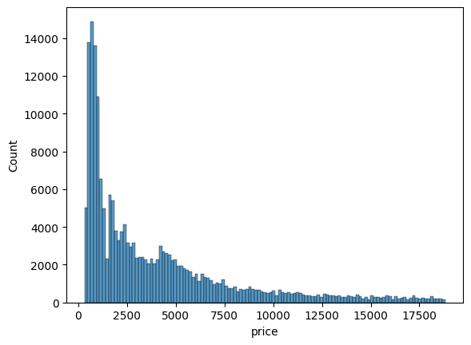

```python
sns.histplot(x ='price', data =train_data)
```

This is either a log-normal distribution or an exponential distribution, hinting that we will likely have to perform some kind of transformation or alternative to basic linear regression model in the future. We perform 3 common transformations here that could have theoretically generated a normal distribution and can use them to our regression techniques.

```python
train_data['natlog_price'] = np.log(train_data['price'])
train_data['log10_price'] = np.log10(train_data['price'])
train_data['box_cox_price'], box_cox_lambda = boxcox(train_data['price'])
```

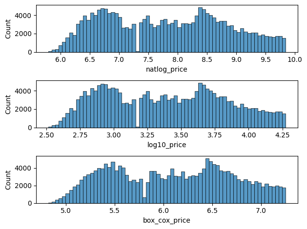

```python
fig, ax = plt.subplots(ncols=1, nrows=3)

sns.histplot(x = 'natlog_price', data = train_data, ax = ax[0])
sns.histplot(x = 'log10_price', data = train_data, ax = ax[1])
sns.histplot(x = 'box_cox_price', data = train_data, ax = ax[2])

fig.tight_layout()
```

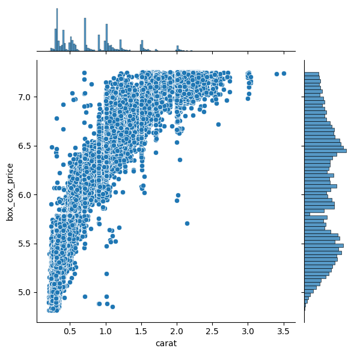

```python
sns.jointplot(x = 'carat', y = 'box_cox_price', data = train_data)
```

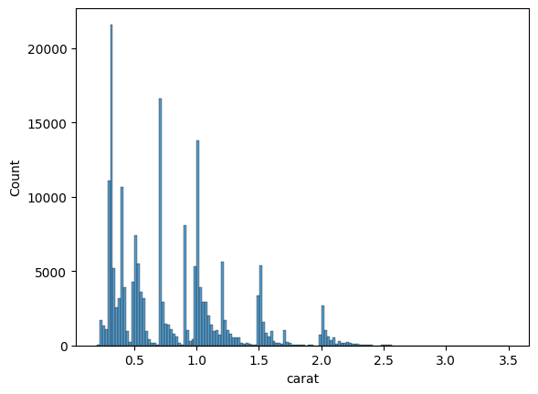

```python
sns.histplot(x = 'carat', data = train_data)
# sns.histplot(x = 'log10_price', data = train_data, ax = ax[1])
# sns.histplot(x = 'box_cox_price', data = train_data, ax = ax[2])
```

Interestingly and noteworthy - the transformations we have performed do not result in a normal distribution. This will likely have negative impacts on our ability to use generalized linear models that assume a normal or single mean distribution.

## Continuous distributions

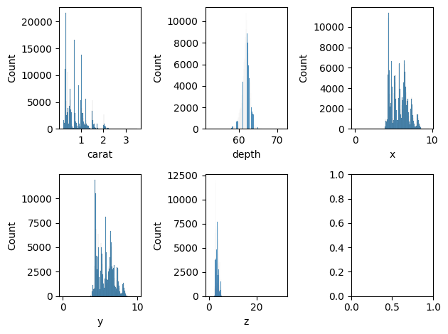

```python
#working to understand our continious distributions
fig, ax = plt.subplots(ncols=3, nrows=2)
sns.histplot(x="carat", data=train_data, ax = ax[0,0])
sns.histplot(x="depth", data=train_data, ax = ax[0,1])
sns.histplot(x="x", data=train_data, ax = ax[0,2])
sns.histplot(x="y", data=train_data, ax = ax[1,0])
sns.histplot(x="z", data=train_data, ax = ax[1,1])

fig.tight_layout()
```

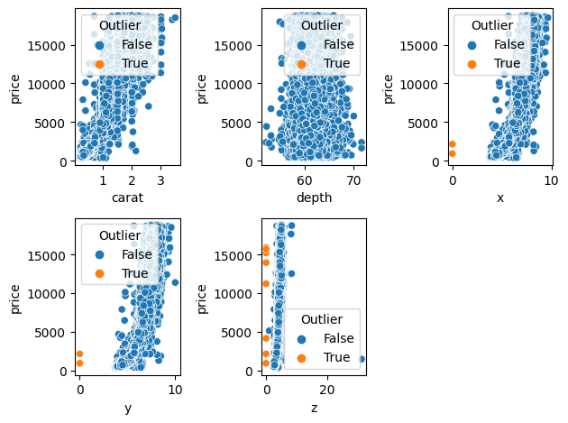

```python
#we can also look at the relationship between these variables and price
fig, ax = plt.subplots(ncols=3, nrows=2)
sns.scatterplot(x="carat",y = 'price', hue = 'Outlier',data=train_data, ax = ax[0,0])
sns.scatterplot(x="depth",y = 'price', hue = 'Outlier',data=train_data, ax = ax[0,1])
sns.scatterplot(x="x",y = 'price', hue = 'Outlier',data=train_data, ax = ax[0,2])
sns.scatterplot(x="y",y = 'price', hue = 'Outlier',data=train_data, ax = ax[1,0])
sns.scatterplot(x="z",y = 'price', hue = 'Outlier',data=train_data, ax = ax[1,1])
fig.delaxes(ax[1,2])

fig.tight_layout()
```

We clearly see additional outliers in our scatter plots

```python
train_data[train_data['z']>20]
```

|  | id | carat | cut | color | clarity | depth | table | x | y | z | price | Outlier | natlog_price | log10_price | box_cox_price |
| --- | --- | --- | --- | --- | --- | --- | --- | --- | --- | --- | --- | --- | --- | --- | --- |
| 167044 | 167044 | 0.51 | Premium | G | VS2 | 61.8 | 58.0 | 5.2 | 5.13 | 31.3 | 1447 | False | 7.277248 | 3.160469 | 5.787916 |

## Categorical Variables

Please note that we include the ordered quality of the 3 categorical variables for logical sake and to understand what kind of gems we have.

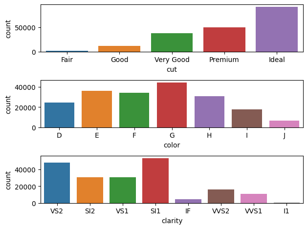

```python
cut_order = ['Fair', 'Good', 'Very Good', 'Premium', 'Ideal']
color_order = sorted(train_data.color.unique())
clarity_order = ['IF','VVS1','VVS2','VS1','VS2','SI1','SI2','I1'].reverse()

fig, ax = plt.subplots(nrows=3)
sns.countplot(x="cut", data=train_data, ax = ax[0], order = cut_order)

sns.countplot(x="color", data=train_data, ax = ax[1], order = color_order)

sns.countplot(x="clarity", data=train_data, ax = ax[2], order = clarity_order)

fig.tight_layout()
```

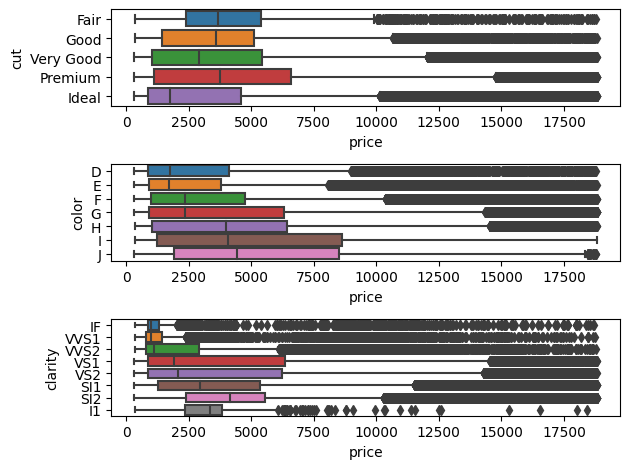

```python
cut_order = ['Fair', 'Good', 'Very Good', 'Premium', 'Ideal']
color_order = sorted(train_data.color.unique())
clarity_order = ['IF','VVS1','VVS2','VS1','VS2','SI1','SI2','I1']

fig, ax = plt.subplots(nrows=3)
sns.boxplot(y="cut", x="price", data=train_data, ax = ax[0], order = cut_order)

sns.boxplot(y="color", x="price", data=train_data, ax = ax[1], order = color_order)

sns.boxplot(y="clarity", x="price", data=train_data, ax = ax[2], order = clarity_order)

fig.tight_layout()
```

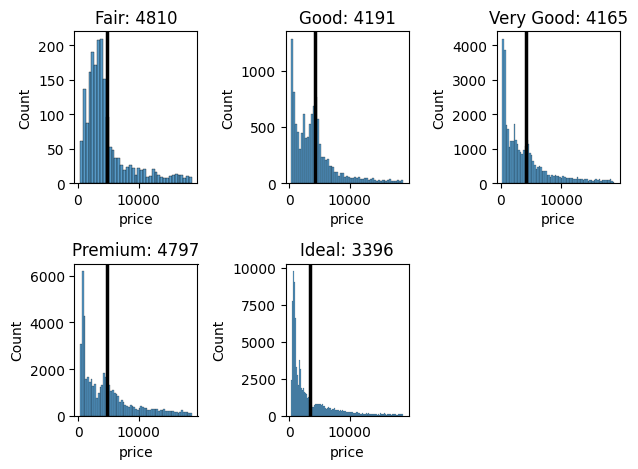

```python
#cuts vs. price
cols = 3
rows = round(len(cut_order)/3)

fig, ax = plt.subplots(ncols=cols, nrows = rows)

curr_col = 0
curr_row = 0

for i,values in enumerate(cut_order):
    mean = train_data[train_data['cut']==cut_order[i]]['price'].mean()
    sns.histplot(x="price",data=train_data[train_data['cut']==cut_order[i]], \
                ax = ax[curr_row,curr_col]).set(title=values+": "+str(int(mean)))
    ax[curr_row,curr_col].axvline(x=mean\
                                  , c='k', ls='-', lw=2.5)
    curr_col+=1
    if curr_col > cols-1:
        curr_row+=1
        curr_col=0
#remove any additional graphs that are not going to be used
while curr_col < cols:
    fig.delaxes(ax[curr_row,curr_col])
    curr_col +=1
fig.tight_layout()
```

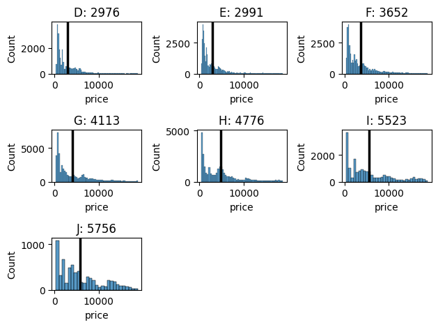

```python
#color vs. price
cols = 3
rows = int(np.ceil(len(color_order)/3))


fig, ax = plt.subplots(ncols=cols, nrows = rows)

curr_col = 0
curr_row = 0

for i,values in enumerate(sorted(color_order)):
    mean = train_data[train_data['color']==color_order[i]]['price'].mean()

    sns.histplot(x="price",data=train_data[train_data['color']==color_order[i]], \
                ax = ax[curr_row,curr_col]).set(title=values+": "+str(int(mean)))
    ax[curr_row,curr_col].axvline(x=mean\
                                  , c='k', ls='-', lw=2.5)
    curr_col+=1
    if curr_col > cols-1:
        curr_row+=1
        curr_col = 0
#remove any additional graphs that are not going to be used
while curr_col < cols:
    fig.delaxes(ax[curr_row,curr_col])
    curr_col +=1
fig.tight_layout()
```

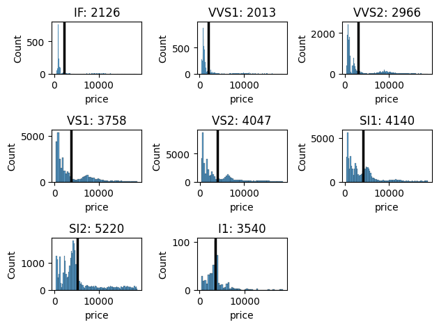

```python
#clarity vs. price

cols = 3
rows = int(np.ceil(len(clarity_order)/3))


fig, ax = plt.subplots(ncols=cols, nrows = rows)

curr_col = 0
curr_row = 0

for i,values in enumerate(clarity_order):
    mean = train_data[train_data['clarity']==clarity_order[i]]['price'].mean()

    sns.histplot(x="price",data=train_data[train_data['clarity']==clarity_order[i]], \
                ax = ax[curr_row,curr_col]).set(title=values+": "+str(int(mean)))

    ax[curr_row,curr_col].axvline(x=mean\
                                  , c='k', ls='-', lw=2.5)
    curr_col+=1
    if curr_col > cols-1:
        curr_row+=1
        curr_col = 0
#remove any additional graphs that are not going to be used
while curr_col < cols:
    fig.delaxes(ax[curr_row,curr_col])
    curr_col +=1
fig.tight_layout()
```

These categorical variables imply that we might be able to model the price of the gems via creating multiple linear regression models based on the differet combinations of categorical variables. (n(clarity) x n(color) x n(color)) which would be 280 different models. This might be possible with our sample size, but we should investigate the sample sizes of the subcategories of diamonds. These subcategories could explain why the cut of the gems increase in quality appears to cause the price to decrease.

## Sizing the different combinations categories of gems

```python
color_cut = train_data.pivot_table(values='id',index='color',columns=['cut'],aggfunc=pd.Series.nunique)
color_cut.fillna(0, inplace=True)

color_clarity = train_data.pivot_table(values='id',index='color',columns=['clarity'],aggfunc=pd.Series.nunique)
color_clarity.fillna(0, inplace=True)

clarity_cut = train_data.pivot_table(values='id',index='clarity',columns=['cut'],aggfunc=pd.Series.nunique)
clarity_cut.fillna(0, inplace=True)

#we need to reorder the different categories so that the best are in the top right
color_cut = color_cut.reindex(color_order)
color_clarity=color_clarity.reindex(color_order)
clarity_cut=clarity_cut.reindex(clarity_order)

color_cut = color_cut.reindex(columns=cut_order)
color_clarity=color_clarity.reindex(columns=clarity_order)
clarity_cut=clarity_cut.reindex(columns=cut_order)
```

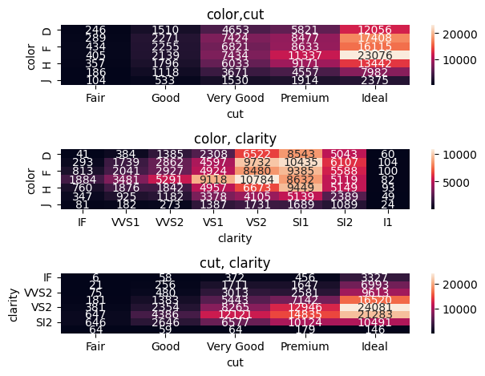

```python
fig, ax = plt.subplots(nrows=3)
#need to change orders here
sns.heatmap(color_cut,annot=True, fmt='d', ax=ax[0]).set(title="color,cut")
sns.heatmap(color_clarity,annot=True, fmt='d', ax=ax[1]).set(title="color, clarity")
sns.heatmap(clarity_cut,annot=True, fmt='d', ax=ax[2]).set(title="cut, clarity")

fig.tight_layout()
```

# Notes & Findings:

1) Outliers have been detected in a couple of different places (see scatterplots for highlights).  
2) The categorical variables predictive power with price to not seem to follow a logical order when viewed independent of others. Color is the exception. It is likely that this lack of price increase as the percieved quality of the diamonds increases is likely due to interaction between clarity and cut and other variables.  
3) The overall distribution of gems seems to be weighted more towards the 'higher' quality side. Traditionally, we might think that as a gems rarity increases, the more valuable it gets - but in our sample size, the "rarer" gems might actually be of lower quality.  
4) We have concerns about the number of records in certain subsamples of our data.

# Feature Engineering / Removal of Outliers

One of our concerns was to the actual values of x,y,z in our model. From both external research on gems as well as the data itself, we make a quick model of the x,y,z variables, assuming carat is correct. Generally speaking, the carat is equivalent to x *y* z / 163.3406 with z being roughly equivalent to .6185 of the x and y values, which are equivalent. We can use this heuristics to impute values for x,y,z in the case that they are either ommitted or obviously incorrect.

```python
df = train_data[train_data['z'] > 0]
print(1/np.mean(df['carat'] / df['x'] / df['y'] / df['z']))
print(np.mean(df['z'] / df['x']))
print(np.mean(df['x'] / df['y']))
```

```
163.3460290359694
0.6185254551805288
0.9989403458958795
```

```python
def add_features(df):
    df = df.copy()

    df['x_estimate'] =  np.cbrt(df['carat'] * 163.3406 / .6185)
    df['y_estimate'] =  np.cbrt(df['carat'] * 163.3406 / .6185)
    df['z_estimate'] = df['y_estimate']*.6185
    df['carat_estimate'] = df['z_estimate'] * df['x_estimate'] * df['y_estimate']
    #replace x,y,z if the x,y,z are blank
    df['z'] = np.where(df['z'] == 0, df['z_estimate'], df['z'])
    df['x'] = np.where(df['x'] == 0, df['x_estimate'], df['x'])
    df['y'] = np.where(df['y'] == 0, df['y_estimate'], df['y'])
    #replace x,y,z if the values of x,y,z are outside of 20% of our expectation
    df['x'] = np.where(df['x'] / df['y'] < .8, df['x_estimate'], df['x'])
    df['x'] = np.where(df['x'] / df['y'] > 1.2, df['x_estimate'], df['x'])

    df['y'] = np.where(df['y'] / df['x'] > 1.2, df['y_estimate'], df['y'])
    df['y'] = np.where(df['y'] / df['x'] > .8, df['y_estimate'], df['y'])

    df['z'] = np.where(df['z'] / df['y'] > .8, df['z_estimate'], df['z'])
    df['z'] = np.where(df['z'] / df['y'] < .4, df['z_estimate'], df['z'])

    df["surface_area"] = 2 * (df["x"] * df["y"] + df["y"] * df["z"] + df["z"] * df["x"])
    df['volume'] = df['x'] * df['y'] * df['z']

    df['GirdleEstimate'] = (df['x'] + df['y']) / 2

    df['DepthEstimate'] = df['z'] / df['GirdleEstimate']
    df['TabletoGirdle'] = df['table'] / df['GirdleEstimate']


    df['carat_size1'] = np.where(df['carat'] < .5, "A.0-.5",\
                                np.where(df['carat'] < 1, "B.5-1",\
                                np.where(df['carat'] < 1.49, "C.1-1.5",\
                                np.where(df['carat'] < 1.99, "D.1.5-2","E.2.0+"))))
    return df
```

```python
def remove_outliers(df):
    '''remove elements that contain 0s'''
    df = df.copy()
    outlier_indexes = df[(df[['x','y','z']] == 0).any(axis=1)].index
    return outlier_indexes
```

```python
def get_model_diagnostics(data):
    '''Assumes that the columns are named error, actual and pred'''
    fig, ax = plt.subplots(ncols=2, nrows=3)
    #normality
    sns.histplot(x = 'error', data = data, ax = ax[0,0]).set(title=f"Normality {x}")
    #linear relationship
    sns.scatterplot(x ='actual', y = 'pred', data = data, ax = ax[0,1]).set(title="Linear Relationship")

    #constant variance
    sns.scatterplot(x = 'pred', y = 'error',data = data, ax = ax[1,0]).set(title="Var: Residuals v. Preds")
    sns.scatterplot(x = 'actual', y = 'error',data = data, ax = ax[1,1]).set(title="Var: Residuals v. Actual")

    #constant variance
    sns.scatterplot(x = 'carat', y ='error', data = data, ax=ax[2,0]).set(title="Variance: Carat vs. Residual")
    fig.delaxes(ax[2,1])
    fig.tight_layout()
```

# Model Building

From here on out we will be iterating through multiple different variations of linear regressions in an attempt to minimize our RMSE, which was the evaluation metric for this competition.

For organizations sake, we can store the RMSE of each model as well as several of the pertinent diagnostics for each model in a dictionary that we can call later in the modeling process to assess our progress.

## Linear Regression w/ transformations

```python
#reload training data
train_data = pd.read_csv("train.csv")
test_data = pd.read_csv("test.csv")

cols = ['carat','cut','clarity','color','volume','surface_area','table','depth']
outliers = remove_outliers(train_data)
train_data.drop(outliers,inplace=True)
train_data = add_features(train_data)
```

We start by creating very basic models with one predictor in order to understand the relationship between our primary predicting variable (carat) and the price of a gem. We iterate and add complexity to our models in an attempt to improve our models predictive power.

This comes on the backdrop of creating a "good" model. We evaluate each model using the main assumptions of linear regression: 1) Normal distribution of error terms  
2) Constant Variance  
3) Linear Relationship

Details on the assumptions (there are a few others) we are driving towards can be found https://www.statology.org/linear-regression-assumptions/

## Additional helper functions

One of the other issues we will run through as we test for the overall significance of our models is the fact that sklearn does not provide a fstat calculation for overall regression signficance. We can create one quickly.

```python
def fstat_linear(X_train, y_train, preds):
    '''n: Sample size,
       k: number of predictors
       '''
    N = len(X_train)
    K = len(X_train.columns)
    r2 = r2_score(y_train, preds)
    return (r2/(1-r2))*((N-K-1)/K)
```

```python
linear_models_diagnostics = {}
```

# Model 1:

Benchmark model with price and carat, untransformed.

```
Model RMSE is ... 1338.0406450416572
```

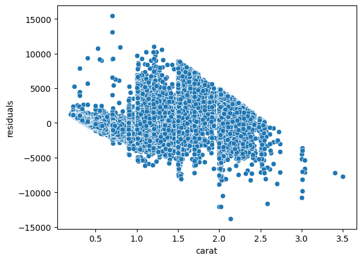

```python
#model1
#basicModel
#import data
train_data = pd.read_csv("train.csv")
test_data = pd.read_csv("test.csv")
outliers = remove_outliers(train_data)
train_data.drop(outliers,inplace=True)
X_train = train_data[['carat']]
y_train = train_data['price']

model_1 = LinearRegression()
model_1.fit(X_train,y_train)
preds = model_1.predict(X_train)
model_1_residuals = (y_train - preds)
model1_mse = mean_squared_error(y_train, preds)


sns.scatterplot(y=model_1_residuals,x=X_train['carat']).set(ylabel="residuals")
print("Model RMSE is ...", np.sqrt(model1_mse))
linear_models_diagnostics['Model1'] = {}
linear_models_diagnostics['Model1']['RMSE'] = np.sqrt(model1_mse)
linear_models_diagnostics['Model1']['RSquared'] = r2_score(y_train, preds)
linear_models_diagnostics['Model1']['FScore'] = fstat_linear(X_train, y_train, preds)
```

```python
linear_models_diagnostics['Model1']
```

```
{'RMSE': 1338.0406450416572,
 'RSquared': 0.8899817543569611,
 'FScore': 1565792.6314696462}
```

# Model 2:

We perform a boxcox transformation the price variable.

```
Model RMSE is ... 10249.464751032085
```

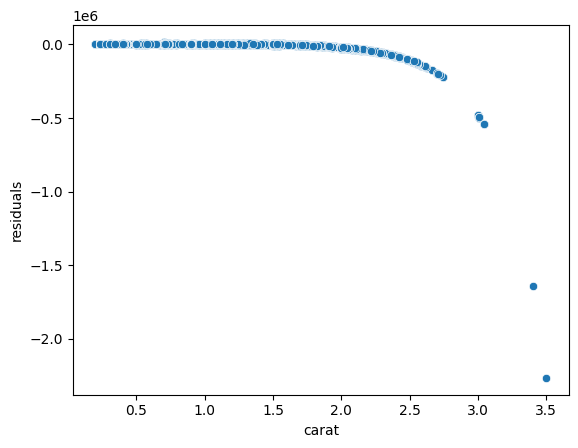

```python
#model2
#Carat Only w/ boxcox transformation
#import data
linear_models_diagnostics['Model2'] = {}
train_data = pd.read_csv("train.csv")
test_data = pd.read_csv("test.csv")
outliers = remove_outliers(train_data)
train_data.drop(outliers,inplace=True)

X_train = train_data[['carat']]
y_train = train_data['price']
y_train, lamb = boxcox(y_train)

model_2 = LinearRegression()
model_2.fit(X_train,y_train)

preds = model_2.predict(X_train)
preds = inv_boxcox(preds, lamb)
y_train = inv_boxcox(y_train, lamb)

model_2_residuals = (y_train - preds)
linear_models_diagnostics['Model2']['RSquared'] = r2_score(y_train,preds)
model2_mse = mean_squared_error(y_train, preds)

sns.scatterplot(y=model_2_residuals,x=X_train['carat']).set(ylabel="residuals")
print("Model RMSE is ...", np.sqrt(model2_mse))

linear_models_diagnostics['Model2']['FScore'] = fstat_linear(X_train, y_train, preds)
linear_models_diagnostics['Model2']['RMSE'] = np.sqrt(model2_mse)
```

Please note that although the scale of the above graph is rather misleading (we are not perfectly modeling the price of carats <1.5, performing a boxcox transformation on the dependent variable still results in the constant variance assumption being violated.

```python
linear_models_diagnostics
```

```
{'Model1': {'RMSE': 1338.0406450416572,
  'RSquared': 0.8899817543569611,
  'FScore': 1565792.6314696462},
 'Model2': {'RSquared': -5.4554790462188105,
  'FScore': -163577.01296911106,
  'RMSE': 10249.464751032085}}
```

# Model 3:

We perform a boxcox transformation on the price and a boxcox transformation on carat.

```
Model RMSE is ... 1296.360087422356
```

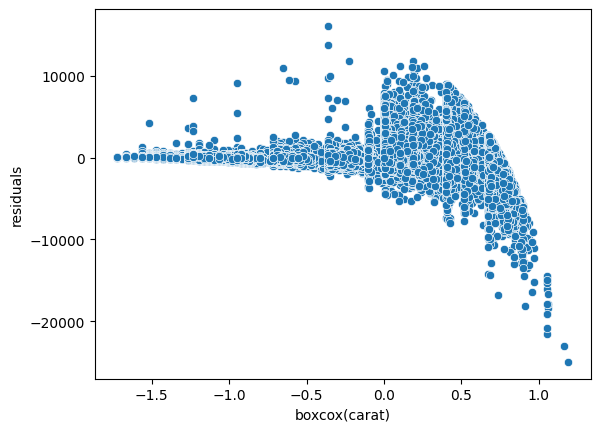

```python
#model3
#boxcox on dependent, boxcox on independent as well
#import data
linear_models_diagnostics['Model3'] = {}

train_data = pd.read_csv("train.csv")
test_data = pd.read_csv("test.csv")
outliers = remove_outliers(train_data)
train_data.drop(outliers,inplace=True)

X_train = train_data[['carat']]
y_train = train_data['price']

X_train['carat'], dep_lambda = boxcox(X_train['carat'])
y_train, lamb = boxcox(y_train)

model_3 = LinearRegression()
model_3.fit(X_train,y_train)

preds = model_3.predict(X_train)


preds = inv_boxcox(preds, lamb)
y_train = inv_boxcox(y_train, lamb)
linear_models_diagnostics['Model3']['RSquared'] = r2_score(y_train,preds)

model_3_residuals = (y_train - preds)

model3_mse = mean_squared_error(y_train, preds)
sns.scatterplot(y=model_3_residuals,x=X_train['carat']).set(xlabel='boxcox(carat)', ylabel ='residuals')

print("Model RMSE is ...", np.sqrt(model3_mse))
linear_models_diagnostics['Model3']['RMSE'] = np.sqrt(model3_mse)
linear_models_diagnostics['Model3']['FScore'] = fstat_linear(X_train, y_train, preds)
```

```python
linear_models_diagnostics
```

```
{'Model1': {'RMSE': 1338.0406450416572,
  'RSquared': 0.8899817543569611,
  'FScore': 1565792.6314696462},
 'Model2': {'RSquared': -5.4554790462188105,
  'FScore': -163577.01296911106,
  'RMSE': 10249.464751032085},
 'Model3': {'RSquared': 0.896729232125834,
  'RMSE': 1296.360087422356,
  'FScore': 1680744.8077756467}}
```

# Model 4:

We perform a boxcox transformation on both price and carat. However, we include the categorical variables as well in an attempt to improve performance

```
Model RMSE is ... 739.1317566872576
```

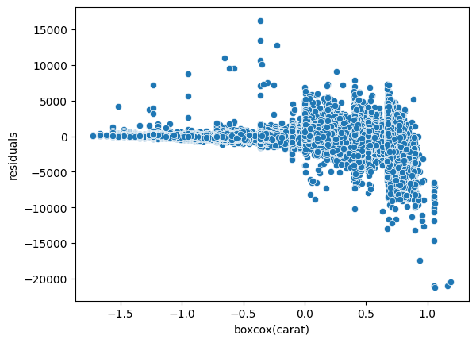

```python
#model4
#boxcox on dependent, boxcox on independent as well, including all categorical variables we have previously ommited
#import data
train_data = pd.read_csv("train.csv")
test_data = pd.read_csv("test.csv")
outliers = remove_outliers(train_data)
train_data.drop(outliers,inplace=True)
linear_models_diagnostics['Model4'] = {}

X_train = pd.get_dummies(train_data[['carat','cut','clarity','color']], columns = ['cut','clarity','color'])
y_train = train_data['price']
X_train['carat'], dep_lambda = boxcox(X_train['carat'])
y_train, lamb = boxcox(y_train)

model_4 = LinearRegression()
model_4.fit(X_train,y_train)


linear_models_diagnostics['Model4']['RSquared'] = r_regression(X_train, y_train)
preds = model_4.predict(X_train)

preds = inv_boxcox(preds, lamb)
y_train = inv_boxcox(y_train, lamb)

model_4_residuals = (y_train - preds)
linear_models_diagnostics['Model4']['RSquared'] = r2_score(y_train,preds)

model_4_MPE_resids = preds / y_train
model_4_MAPE = mean_absolute_percentage_error(y_train, preds)
model4_mse = mean_squared_error(y_train, preds)
# sns.scatterplot(y=model_3_residuals,x=X_train['carat'])
sns.scatterplot(y=model_4_residuals,x=X_train['carat']).set(xlabel='boxcox(carat)', ylabel ='residuals')
print("Model RMSE is ...", np.sqrt(model4_mse))
linear_models_diagnostics['Model4']['RMSE'] = np.sqrt(model4_mse)
linear_models_diagnostics['Model4']['FScore'] = fstat_linear(X_train, y_train, preds)
```

We can see that the constant variance assumption is still being violated, but our models performance is getting substantially better.

```python
linear_models_diagnostics
```

```
{'Model1': {'RMSE': 1338.0406450416572,
  'RSquared': 0.8899817543569611,
  'FScore': 1565792.6314696462},
 'Model2': {'RSquared': -5.4554790462188105,
  'FScore': -163577.01296911106,
  'RMSE': 10249.464751032085},
 'Model3': {'RSquared': 0.896729232125834,
  'RMSE': 1296.360087422356,
  'FScore': 1680744.8077756467},
 'Model4': {'RSquared': 0.9664285710193106,
  'RMSE': 739.1317566872576,
  'FScore': 265309.9996928332}}
```

# Model 5:

Boxbox transform both the dependent and independent variable, but introduce a variable indicating whether or not the carat is greater than 1 in an attempt to stratify the model in order to facilitate some kind of adjustement in order to improve the predictive power of the model at higher weighted carats.

```
Model RMSE is ... 691.6797568286372
```

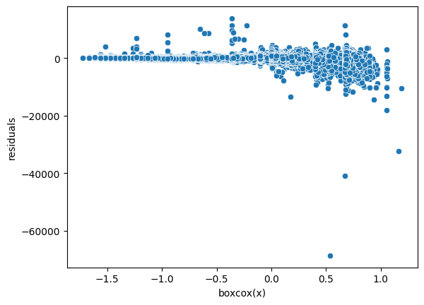

```python
#model_5
#boxcox on dependent, boxcox on independent as well and then we include categorical vars as well
#as a variable indicating that carat >1
#import data
train_data = pd.read_csv("train.csv")
test_data = pd.read_csv("test.csv")
outliers = remove_outliers(train_data)
train_data.drop(outliers,inplace=True)
linear_models_diagnostics['Model5'] = {}

X_train = pd.get_dummies(train_data, columns = ['cut','clarity','color'])
X_train['caratover1'] = np.where(X_train['carat']>1,1,0)
X_train['carat'], dep_lambda = boxcox(X_train['carat'])
y_train, lamb = boxcox(y_train)

final_model = LinearRegression()
final_model.fit(X_train,y_train)
linear_models_diagnostics['Model5']['FScore'] = f_regression(X_train, y_train)

preds = final_model.predict(X_train)


preds = inv_boxcox(preds, lamb)
y_train = inv_boxcox(y_train, lamb)

model5_residuals = (y_train - preds)

linear_models_diagnostics['Model5']['RSquared'] = r2_score(y_train,preds)
model5_MPE_resids = preds / y_train
model5_MAPE = mean_absolute_percentage_error(y_train, preds)
model5_mse = mean_squared_error(y_train, preds)
# sns.scatterplot(y=model_3_residuals,x=X_train['carat'])
sns.scatterplot(y=model5_residuals,x=X_train['carat']).set(xlabel='boxcox(x)', ylabel ='residuals')
df_model_5 = train_data.copy()
df_model_5['residuals'] = model5_residuals
df_model_5['preds'] = preds
df_model_5['y_train'] = y_train
df_model_5['mispriced'] = np.where(abs(df_model_5['residuals']) > 10000,"True","False")
print("Model RMSE is ...", np.sqrt(model5_mse))
linear_models_diagnostics['Model5']['RMSE'] = np.sqrt(model5_mse)
linear_models_diagnostics['Model5']['FScore'] = fstat_linear(X_train, y_train, preds)
```

We can see from the above that we are still (overall) improving our RMSE, but the residuals continue to increase as our carat value increases. We can perform some more detailed diagnostics in an attempt to understand what factors are causing this to occur. We identify records which we are mispredicting by over 10000 dollars and try to identify them using various scatter plots.

```python
linear_models_diagnostics
```

```
{'Model1': {'RMSE': 1338.0406450416572,
  'RSquared': 0.8899817543569611,
  'FScore': 1565792.6314696462},
 'Model2': {'RSquared': -5.4554790462188105,
  'FScore': -163577.01296911106,
  'RMSE': 10249.464751032085},
 'Model3': {'RSquared': 0.896729232125834,
  'RMSE': 1296.360087422356,
  'FScore': 1680744.8077756467},
 'Model4': {'RSquared': 0.9664285710193106,
  'RMSE': 739.1317566872576,
  'FScore': 265309.9996928332},
 'Model5': {'FScore': 220323.80311183044,
  'RSquared': 0.9706007511454909,
  'RMSE': 691.6797568286372}}
```

```python
df_model_5['carat_size1'] = np.where(df_model_5['carat'] < .5, "A.0-.5",\
                                np.where(df_model_5['carat'] < 1, "B.5-1",\
                                np.where(df_model_5['carat'] < 1.49, "C.1-1.5",\
                                np.where(df_model_5['carat'] < 1.99, "D.1.5-2",\
                                np.where(df_model_5['carat'] < 2.49, "E.2.0-2.5",\
                                np.where(df_model_5['carat'] < 2.99, "F.2.5-3","G.3+"))))))
```

```python
records = {}
for x in sorted(df_model_5['carat_size1'].unique()):
    records[x] = np.sqrt(mean_squared_error(df_model_5[df_model_5['carat_size1'] == x]['price'],\
                             df_model_5[df_model_5['carat_size1'] == x]['preds']))
```

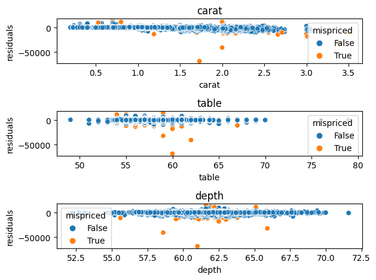

```python
fig, ax = plt.subplots(nrows=3)
sns.scatterplot(y='residuals',x='carat',hue='mispriced', data = df_model_5,ax = ax[0])\
    .set(xlabel='carat', ylabel ='residuals',title="carat")

sns.scatterplot(y='residuals',x='table',hue='mispriced', data = df_model_5,ax = ax[1])\
    .set(xlabel='table', ylabel ='residuals',title="table")

sns.scatterplot(y='residuals',x='depth',hue='mispriced', data = df_model_5, ax = ax[2])\
    .set(xlabel='depth', ylabel ='residuals',title="depth")
fig.tight_layout()
```

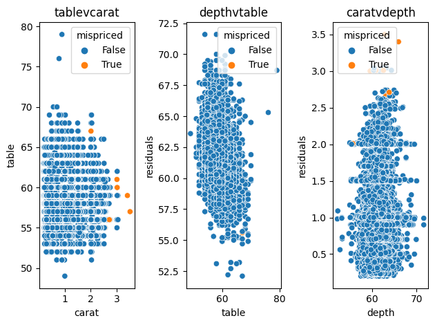

```python
fig, ax = plt.subplots(ncols=3)
sns.scatterplot(y='table',x='carat',hue='mispriced', data = df_model_5,ax = ax[0])\
    .set(xlabel='carat', ylabel ='table',title="tablevcarat")

sns.scatterplot(y='depth',x='table',hue='mispriced', data = df_model_5,ax = ax[1])\
    .set(xlabel='table', ylabel ='residuals',title="depthvtable")

sns.scatterplot(y='carat',x='depth',hue='mispriced', data = df_model_5, ax = ax[2])\
    .set(xlabel='depth', ylabel ='residuals',title="caratvdepth")
fig.tight_layout()
```

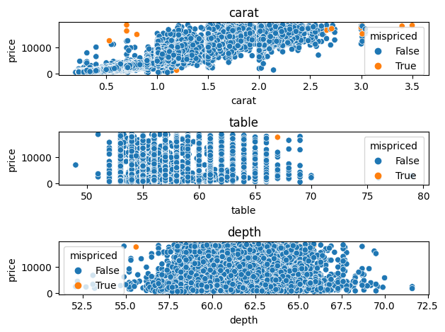

```python
fig, ax = plt.subplots(nrows=3)
sns.scatterplot(y='price',x='carat',hue='mispriced', data = df_model_5,ax = ax[0])\
    .set(xlabel='carat', ylabel ='price',title="carat")

sns.scatterplot(y='price',x='table',hue='mispriced', data = df_model_5,ax = ax[1])\
    .set(xlabel='table', ylabel ='price',title="table")

sns.scatterplot(y='price',x='depth',hue='mispriced', data = df_model_5, ax = ax[2])\
    .set(xlabel='depth', ylabel ='price',title="depth")
fig.tight_layout()
```

We can see from the above that it does not appear that these largely mispriced records are being sourced from any particular part of the features which we were not employing. Our initial assessment that the variation is larger at higher carats is really the only insight we can continue to takeaway from the continious variables.

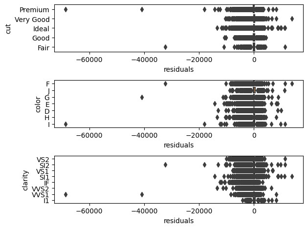

```python
#categorical variables vs. residuals
cols = 1
rows = 3

fig, ax = plt.subplots(ncols=cols, nrows = rows)

curr_col = 0
curr_row = 0

sns.boxplot(y="cut", x = 'residuals', data=df_model_5, ax=ax[0])
sns.boxplot(y="color", x = 'residuals', data=df_model_5, ax=ax[1])
sns.boxplot(y="clarity", x = 'residuals', data=df_model_5, ax=ax[2])

#remove any additional graphs that are not going to be used
fig.tight_layout()
```

# Model 6:

In one last attempt to model higher carats, lets add all features previously mentioned (including a categorical variable for whether or not the carat is larger than 1) and see if we can improve performance. We can perform the same boxcox transformations as before.

```
Model RMSE is ... 695.4615653140906
```

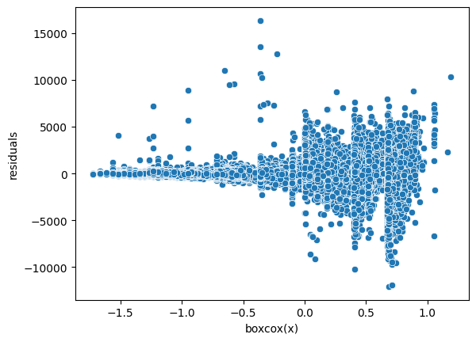

```python
#adding features and removing outliers
#model_6
#boxcox on dependent, boxcox on independent as well, both are log transformations and then we include categorical vars as well
#as a variable indicating that carat >1
#import data
train_data = pd.read_csv("train.csv")
test_data = pd.read_csv("test.csv")
linear_models_diagnostics['Model6'] = {}

var_list = ['cut','clarity','color','carat','depth','table','surface_area','volume','GirdleEstimate','DepthEstimate',\
           'TabletoGirdle', 'carat_size1']
df = add_features(df=train_data)

X_train = pd.get_dummies(df[var_list], columns = ['cut','clarity','color','carat_size1'])
y_train = df['price']
X_train['carat'], dep_lambda = boxcox(X_train['carat'])
y_train, lamb = boxcox(y_train)

model_6 = LinearRegression()
model_6.fit(X_train,y_train)
preds = model_6.predict(X_train)


preds = inv_boxcox(preds, lamb)
y_train = inv_boxcox(y_train, lamb)

model6_residuals = (y_train - preds)
model6_MPE_resids = preds / y_train
model6_MAPE = mean_absolute_percentage_error(y_train, preds)
model6_mse = mean_squared_error(y_train, preds)
# sns.scatterplot(y=model_3_residuals,x=X_train['carat'])
sns.scatterplot(y=model6_residuals,x=X_train['carat']).set(xlabel='boxcox(x)', ylabel ='residuals')
print("Model RMSE is ...", np.sqrt(model6_mse))
linear_models_diagnostics['Model6']['RMSE'] = np.sqrt(model6_mse)
linear_models_diagnostics['Model6']['RSquared'] = r2_score(y_train,preds)
linear_models_diagnostics['Model6']['FScore'] = fstat_linear(X_train, y_train, preds)
```

Unfortunately, throwing the kitchen sink doesn't improve our performance. We still have violations of constant variance. However, our transformations and model feature selections have improve performance, but we are not experiencing only incremental improvements.

```python
linear_models_diagnostics
```

```
{'Model1': {'RMSE': 1338.0406450416572,
  'RSquared': 0.8899817543569611,
  'FScore': 1565792.6314696462},
 'Model2': {'RSquared': -5.4554790462188105,
  'FScore': -163577.01296911106,
  'RMSE': 10249.464751032085},
 'Model3': {'RSquared': 0.896729232125834,
  'RMSE': 1296.360087422356,
  'FScore': 1680744.8077756467},
 'Model4': {'RSquared': 0.9664285710193106,
  'RMSE': 739.1317566872576,
  'FScore': 265309.9996928332},
 'Model5': {'FScore': 220323.80311183044,
  'RSquared': 0.9706007511454909,
  'RMSE': 691.6797568286372},
 'Model6': {'RMSE': 695.4615653140906,
  'RSquared': 0.9702836018356267,
  'FScore': 191494.83992269097}}
```

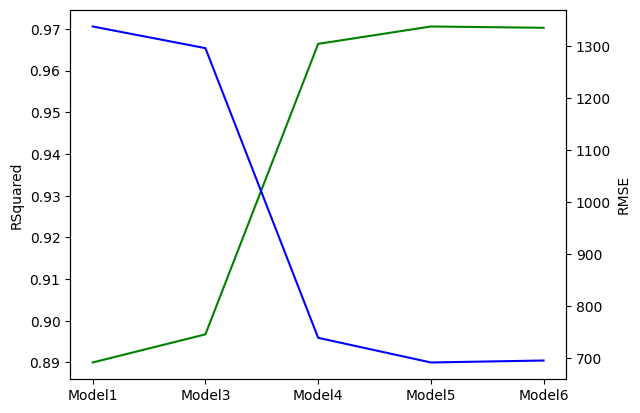

```python
df = pd.DataFrame(linear_models_diagnostics)
df2 = df.transpose()

df2.drop(index='Model2', axis=0, inplace=True)

# sns.lineplot(data=df2, x=['Model1', 'Model2', 'Model3', 'Model4', 'Model5', 'Model6'], y="FScore")
sns.lineplot(data=df2, x=['Model1', 'Model3', 'Model4', 'Model5', 'Model6'], y="RSquared", color = 'g')
ax2 = plt.twinx()
# sns.lineplot(data=df.column2, color="b", ax=ax2)
sns.lineplot(data=df2, x=['Model1', 'Model3', 'Model4', 'Model5', 'Model6'], y="RMSE", ax=ax2, color = 'b')
```

Note that we disregarded model2 since its fit was so poor that it was irrelevant for our consideration.

# Pulling up

At this point, we do not see any additional feature that seems to be associated with differentiated variance or residuals besides the carat. Color, cut and clarity had relatively similar residuals, but carat appears to be the larger issue. However, as noted during EDA we do have concerns about the subsample populations of each cut, color, clarity combination. To help size the problem, lets make sure that the carat is not associated with a particular subgroup of those combinations.

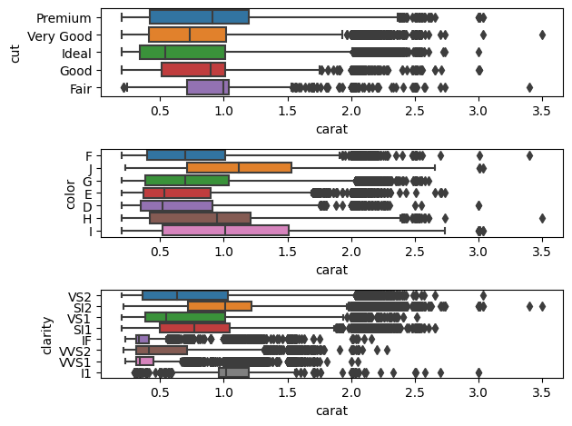

```python
#categorical variables vs. residuals
cols = 1
rows = 3

fig, ax = plt.subplots(ncols=cols, nrows = rows)

curr_col = 0
curr_row = 0

sns.boxplot(y="cut", x = 'carat', data=train_data, ax=ax[0])
sns.boxplot(y="color", x = 'carat', data=train_data, ax=ax[1])
sns.boxplot(y="clarity", x = 'carat', data=train_data, ax=ax[2])

#remove any additional graphs that are not going to be used
fig.tight_layout()
```

# Stratifying our Data and Models

As noted during early EDA of the response variable, price appears to be some kind of bimodal distribution. At this point, we have created multiple linear models, but all of them have some degree of incorrect fitting. We have performed multiple transformations but our residuals violate constant variance assumptions and we need to solve for our inability to properly model prices at higher carat. Here, we implement a few different stratified linear models, with the core goal of capturing the non-normal distribution of our transformed response variable. Essentially what we want to do is create multiple generalized linear models with flexibility for the design of the model to better fit a subset of our data. In the context of what we have previously discussed - we want our model to be able to better model different subsections of the carat size.

```python
train_data = pd.read_csv("train.csv")
test_data = pd.read_csv("test.csv")
outliers = remove_outliers(train_data)
train_data.drop(outliers,inplace=True)
train_data = add_features(train_data)
```

# Model 1:

We create multiple regression models, based on the carat size of the records with no kinds of transformations, and use the combination of the models to undertand that models performance.

```python
#first iteration is w/o any transformations
final_model = {}
multiple_models = pd.DataFrame(columns = ['class','carat','pred','actual'])
for x in train_data['carat_size1'].unique():
    final_model[x] = {}
    temp_df = train_data[train_data['carat_size1'] == x]
    temp_df.reset_index(inplace = True)
    temp_model = LinearRegression()
    temp_x = pd.get_dummies(temp_df[['carat','cut','clarity','color']], columns = ['cut','clarity','color'])
    temp_y = temp_df['price']

    #transformations
    #no transformations
    #fit the model
    temp_model.fit(temp_x, temp_y)

    #untransformations
    #no need to reverse

    #get predictions and diagnostics
    preds = temp_model.predict(temp_x)
    df=pd.concat([temp_df['carat_size1'],temp_df['carat'],pd.Series(preds) ,temp_y], \
                 axis=1)
    df.set_axis(['class','carat','pred','actual'], axis=1,inplace=True)

    df['error'] = df['pred'] - df['actual']
    final_model[x]['MSE'] = np.sqrt(mean_squared_error(df['pred'],df['actual']))
    final_model[x]['Model'] = temp_model
    final_model[x]['DF'] = df
```

```python
combinatory1_mse = []
for x in train_data['carat_size1'].unique():
    combinatory1_mse.append(list(final_model[x]['DF']['error']**2))
errors = [x for l in combinatory1_mse for x in l]
np.sqrt(np.mean(errors))
```

```
634.3798451138622
```

The overall RMSE of the combinatory model is ~634, which is an improvement upon nearly all of our previous models.

# Model 2:

We perform the same process, but now we transform the price variable using the boxcox methodology. Importantly, we are performing multiple different transformations on our price data. We are assuming that the response variable follows a different distribution at different levels of carats.

```python
#Second iteration w/ target transform

strat_model_target_xformed = {}
multiple_models = pd.DataFrame(columns = ['class','carat','pred','actual','preds_xformed','actual_xformed'])
for x in sorted(train_data['carat_size1'].unique()):
    strat_model_target_xformed[x] = {}
    temp_df = train_data[train_data['carat_size1'] == x]
    temp_df.reset_index(inplace = True)
    temp_model = LinearRegression()
    temp_x = pd.get_dummies(temp_df[['carat','cut','clarity','color']], columns = ['cut','clarity','color'])
    temp_y = temp_df['price']

    #transformations
    temp_y, lamb = boxcox(temp_y)

    #fit the model
    temp_model.fit(temp_x, temp_y)

    #get predictions and diagnostics
    preds = temp_model.predict(temp_x)
    #reverse transformations
    preds_xformed = preds
    actual_xformed = temp_y
    preds = inv_boxcox(preds, lamb)
    temp_y = inv_boxcox(temp_y, lamb)

    df=pd.concat([temp_df['carat_size1'],temp_df['carat'],pd.Series(preds) ,pd.Series(temp_y),pd.Series(preds_xformed) ,pd.Series(actual_xformed)], \
                 axis=1)
    df.set_axis(['class','carat','pred','actual','preds_xformed','actual_xformed'], axis=1,inplace=True)

    df['error'] = df['pred'] - df['actual']
    strat_model_target_xformed[x]['Model'] = temp_model
    strat_model_target_xformed[x]['DF'] = df
    strat_model_target_xformed[x]['lambda_y'] = lamb
    strat_model_target_xformed[x]['MSE'] = np.sqrt(np.mean(df['error']**2))
```

```python
combinatory2_mse = []
for x in train_data['carat_size1'].unique():
    combinatory2_mse.append(list(strat_model_target_xformed[x]['DF']['error']**2))
errors = [x for l in combinatory2_mse for x in l]
errors = [x for x in errors if not np.isnan(x)]
np.sqrt(np.mean(errors))
```

```
613.9893974386822
```

Once again, our model improves in terms of its RMSE. Please note that several values of our predictions have to be from nans due to the functionality of inverting the boxcox transformation.

# Model 3:

We transform both the price and carat variable. We also keep the cut, clarity and color columns in our model in order to account for those categorical variables.

```python
all_vars_y_xformed = {}
multiple_models = pd.DataFrame(columns = ['class','carat','pred','actual','preds_xformed','actual_xformed'])

for x in sorted(train_data['carat_size1'].unique()):
    cols = ['carat','cut','color','clarity'\
#             ,'depth','table','surface_area','volume','GirdleEstimate',\
#             'DepthEstimate','TabletoGirdle'\
           ]
    all_vars_y_xformed[x] = {}
    temp_df = train_data[train_data['carat_size1'] == x]
    temp_df.reset_index(inplace = True)
    temp_model = LinearRegression()
    temp_x = pd.get_dummies(temp_df[cols], columns = ['cut','clarity','color'])
    temp_y = temp_df['price']


    #transformations
    temp_y, lamb = boxcox(temp_y)
    temp_x['carat'], lamb2 = boxcox(temp_x['carat'])
    #fit the model
    temp_model.fit(temp_x, temp_y)

    #get predictions and diagnostics
    preds = temp_model.predict(temp_x)
    #reverse transformations
    preds_xformed = preds
    actual_xformed = temp_y
    preds = inv_boxcox(preds, lamb)
    temp_y = inv_boxcox(temp_y, lamb)
    df=pd.concat([temp_df['carat_size1'],temp_df['carat'],pd.Series(preds) ,pd.Series(temp_y),pd.Series(preds_xformed) ,pd.Series(actual_xformed)], \
                 axis=1)
    df.set_axis(['class','carat','pred','actual','preds_xformed','actual_xformed'], axis=1,inplace=True)
    df = df[~df.isna().any(axis=1)]
    df['error'] = df['actual'] - df['pred']

    all_vars_y_xformed[x]['Model'] = temp_model
    all_vars_y_xformed[x]['DF'] = df
    all_vars_y_xformed[x]['lambda_y'] = lamb
    all_vars_y_xformed[x]['MSE'] = np.sqrt(np.mean(df['error']**2))
```

```python
combinatory3_mse = []
for x in train_data['carat_size1'].unique():
    combinatory3_mse.append(list(all_vars_y_xformed[x]['DF']['error']**2))
errors = [x for l in combinatory3_mse for x in l]
errors = [x for x in errors if not np.isnan(x)]
np.sqrt(np.mean(errors))
```

[output not shown]

```python
train_data = pd.read_csv("train.csv")
test_data = pd.read_csv("test.csv")
outliers = remove_outliers(train_data)
train_data.drop(outliers,inplace=True)
train_data = add_features(train_data)
```

# Final Model:

Finally, we transform carat and price with the additional features added.

```python
all_vars_both_xformed = {}
multiple_models = pd.DataFrame(columns = ['class','carat','pred','actual','preds_xformed','actual_xformed'])
scale = False
for x in sorted(train_data['carat_size1'].unique()):
    cols = ['carat','cut','color','clarity'\
            ,'depth','table','surface_area','volume','GirdleEstimate',\
            'DepthEstimate','TabletoGirdle'\
           ]
    cont_cols = ['carat','depth','table','surface_area',\
                 'volume','GirdleEstimate',\
                'DepthEstimate','TabletoGirdle'\
                ]
    all_vars_both_xformed[x] = {}
    temp_df = train_data[train_data['carat_size1'] == x]
    temp_df.reset_index(inplace = True)
    temp_model = LinearRegression()
    temp_x = pd.get_dummies(temp_df[cols], columns = ['cut','clarity','color'])
    temp_y = temp_df['price']

    temp_x['carat'], lambda_x = boxcox(temp_x['carat'])

    if scale == True:
        temp_x[cont_cols] = StandardScaler().fit_transform(temp_x[cont_cols])

    #transformations
    temp_y, lambda_y = boxcox(temp_y)
    #fit the model
    temp_model.fit(temp_x, temp_y)

    #get predictions and diagnostics
    preds = temp_model.predict(temp_x)
    #reverse transformations
    preds_xformed = preds
    actual_xformed = temp_y
    preds = inv_boxcox(preds, lambda_y)
    temp_y = inv_boxcox(temp_y, lambda_y)

    df=pd.concat([temp_df['carat_size1'],temp_df['carat'],pd.Series(preds) ,pd.Series(temp_y),pd.Series(preds_xformed) ,pd.Series(actual_xformed)], \
                 axis=1)
    df.set_axis(['class','carat','pred','actual','preds_xformed','actual_xformed'], axis=1,inplace=True)
    df = df[~df.isna().any(axis=1)]

    df['error'] = df['actual'] - df['pred']

    all_vars_both_xformed[x]['Model'] = temp_model
    all_vars_both_xformed[x]['DF'] = df
    all_vars_both_xformed[x]['lambda_y'] = lambda_y
    all_vars_both_xformed[x]['lambda_x'] = lambda_x
    all_vars_both_xformed[x]['MSE'] = np.sqrt(np.mean(df['error']**2))
```

```python
combinatory4_mse = []
for x in train_data['carat_size1'].unique():
    combinatory4_mse.append(list(all_vars_both_xformed[x]['DF']['error']**2))
errors = [x for l in combinatory4_mse for x in l]
errors = [x for x in errors if not np.isnan(x)]
np.sqrt(np.mean(errors))
```

```
607.6227080210058
```

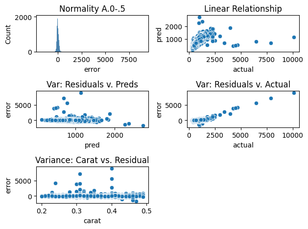

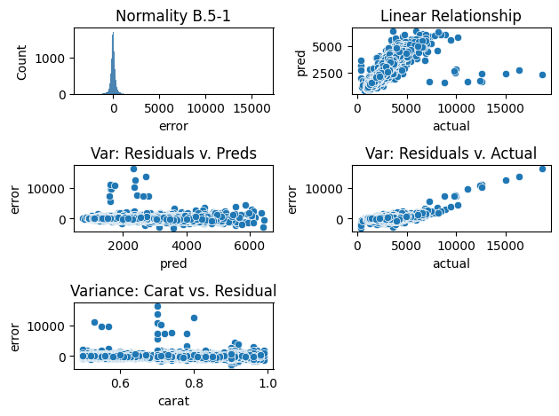

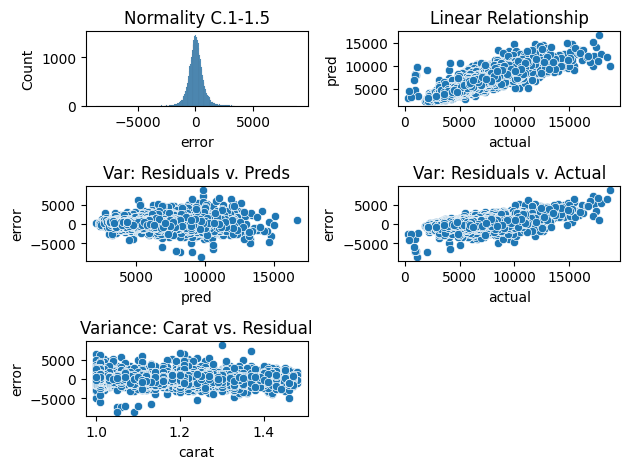

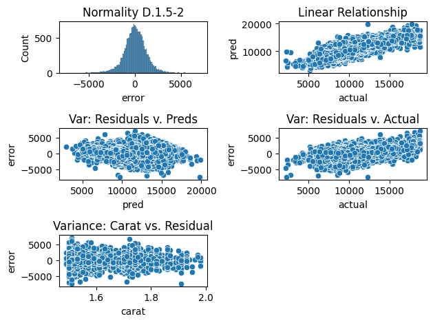

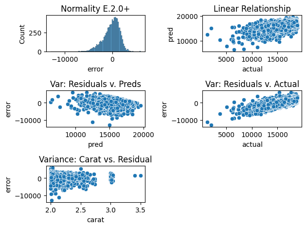

```python
for x in sorted(all_vars_both_xformed.keys()):
    get_model_diagnostics(all_vars_both_xformed[x]['DF'])
```

## Create the Test Model

```python
test_data = pd.read_csv("test.csv")
test_data = add_features(test_data)
pred_list=pd.DataFrame(columns = ['id','price'])
for x in test_data['carat_size1'].unique():
    #fit based on the appropriate model
    cols = ['carat','cut','color','clarity']

    #get the IDs
    ids = test_data[test_data['carat_size1']==x]['id']


    data = pd.get_dummies(test_data[cols], columns = ['cut','clarity','color'])
    preds = final_model[x]['Model'].predict(data[test_data['carat_size1']==x])

    #link based on ID
    df = pd.DataFrame({'id': ids,
                       'price': preds})
#add new row to end of DataFrame
    pred_list = pred_list.append(df, ignore_index = False)
test_data = test_data.merge(pred_list, how = 'left', on ='id')
test_data.set_index('id',inplace=True)
test_data[['price']].to_csv("submission.csv")
```

# Critique and Commentary

This was a difficult set of data due to the sampling issues associated with it. I'll touch on a few.

1) I wanted to use downsampling / upsampling in order to solve for what I perceived to be an issue in the subsamples sizing noted within this script several times. I believe that the models are being influenced by outsized numbers of certain cut/clarity/color combinations, which continiously cause issues with the accuracy of the model when it comes to other cut/clarity/color combinations which have lower weights within any individual subset. The level of upsampling necessary was too much for my machine to handle and downsampling did not yield improvement.

2) Feature engineering and outlier removal could have been more robust. I prioritized iterating within my models to understand what the underlying issues were with my models vs. trying to synthesize a perfect dataset. Kaggle does not release details on the outliers or the generative process for creating the data, so I feel fairly convinced that there was some data-integrity issues that I missed.

3) As noted in the introduction, I attempted many, many other generalized linear models during this process that I did not include in this final notebook. I trained mutliple different models based on the cut/clarity/color of the gem or the combination of the three. These models took exceptionally long to generate and did not truly improve the performance of the models.

4) One key learning for me was the ability to quickly iterate between models. I would have liked to have formalized the pipeline process and feature selection process in some kind of class/method so that I could have more easily understood where my models needed to be tuned. Using linear regression in python can sometimes be a bit limiting (unlike in R, where one has access to many more statistical tuning tools), so I would have liked to have set up a framework initially to more quickly iterate. A good example of that is the function that I used to visualize the assumptions of linear regression mentioned in the intro. That functionality is native in R.

5) Finally, something I will include in subsequent iterations of this work, will a more robust analysis of the different models. I will add checks for VIF, partial F-test model comparisons etc. As noted in the introduction, much of the initial model building was done more as experimentation rather than robust model selection, but it is something that should be interwoven throughout the process in future iterations to aid in my understanding of each individual models performance and improvement relative to others.

# Submission Performance

The final model submitted did perform well overall, placing about 10% off from the best performing models, which as shown on the kaggle leaderboard, generally leverage a host of ensemble models which have been tuned exeptionally rigorously. This exercise was not about finding the best performing model, but rather attempting to form the best linear model possible. I feel that these linear models represent nearly as good as a performing model as can be created, without the exceptional ambiguity of training multiple ensemble models with all features and without a fundamental understanding for the reasons behind their performance.

https://www.kaggle.com/competitions/playground-series-s3e8/leaderboard